# CS5801 Coursework Template Proforma

2219246

02 enero, 2023

```r
#install.packages("rpart.plot")
library(validate)
library(tidyverse)
library(ggplot2)
library(rpart.plot)
```

# 1. Organise and clean the data

## 1.1 Subset the data into the specific dataset allocated

```r
SID <- 2219246
SIDoffset <- (SID %% 100) + 1

load("house-analysis.RDa")

mydf <- house.analysis[seq(from=SIDoffset,to=nrow(house.analysis),by=100),]
```

## 1.2 Data quality analysis

The following points will be checked to assess the data quality:

- What type of data are we working with? Are data types correct? Do the values make sense?
- Are there erratic values? Are there more categories than expected for categorical variables?
- Are there any missing values? How am I going to deal with them?

First off, we can eyeball the data to answer the first question:

```r
View(mydf)
```

We can see at first sight that the row numbers are matched with the Id’s. This should be changed immediately to avoid future complications. As it can be seen, the data frame includes 904 observations, therefore:

```r
rownames(mydf) <- c(1:904)
```

This way, every row is enumerated independently from the property ID. Now, the variable names can be simplified for convenience and faster coding, while maintaining the explainability of the names. Moreover, “mq” is an Italian term for “square meters”, so it will be changed to “sqm”:

```r
names(mydf)[3] <- "sqm"
names(mydf)[5] <- "rooms"
names(mydf)[6] <- "bathrooms"
names(mydf)[7] <- "terrace"
names(mydf)[8] <- "alarm"
names(mydf)[9] <- "heating"
names(mydf)[10] <- "ac"
names(mydf)[11] <- "parking"
names(mydf)[12] <- "furnished"
```

```r
str(mydf)
```

```
## 'data.frame':    904 obs. of  12 variables:
##  $ id       : int  94 281 485 675 959 1160 1390 1684 1978 2248 ...
##  $ price    : num  137000 170000 160000 62000 169000 229000 39000 39000 180000 34000 ...
##  $ sqm      : num  115 70 180 47 180 180 110 45 100 65 ...
##  $ floor    : num  2 1 1 4 2 1 1 2 1 1 ...
##  $ rooms    : num  5 3 5 2 5 4 5 2 4 3 ...
##  $ bathrooms: num  2 1 1 1 3 3 2 1 2 1 ...
##  $ terrace  : int  0 1 1 0 0 0 0 0 0 0 ...
##  $ alarm    : int  0 0 0 0 0 0 0 0 0 0 ...
##  $ heating  : chr  "autonomous" "autonomous" "autonomous" "autonomous" ...
##  $ ac       : int  0 1 0 1 1 0 0 1 0 1 ...
##  $ parking  : int  0 0 0 0 0 0 0 0 0 0 ...
##  $ furnished: int  0 0 0 0 0 0 0 1 0 0 ...
```

The data set contains 904 rows and 12 columns. The “id” column is not relevant for our study. Further mistakes can be spotted: Firstly, categorical variables (which are all of them except for “price” and “sqm”) are not considered as factors. Moreover, we can see that heating is considered as character, hinting at an error. We can begin by correcting the data types:

```r
mydf$floor <- as.factor(mydf$floor)
mydf$rooms <- as.factor(mydf$rooms)
mydf$bathrooms <- as.factor(mydf$bathrooms)
mydf$terrace <- as.factor(mydf$terrace)
mydf$alarm <- as.factor(mydf$alarm)
mydf$heating <- as.factor(mydf$heating)
mydf$ac <- as.factor(mydf$ac)
mydf$parking <- as.factor(mydf$parking)
mydf$furnished <- as.factor(mydf$furnished)
```

We can now take a deeper look into the data:

```r
summary(mydf)
```

```
##        id             price             sqm        floor   rooms    bathrooms
##  Min.   :    94   Min.   :  1000   Min.   :  0.0   1:443   -1:  1   1:548
##  1st Qu.: 53967   1st Qu.: 75000   1st Qu.: 75.0   2:284   2 :162   2:319
##  Median :113209   Median :120000   Median :100.0   3:119   3 :355   3: 37
##  Mean   :111118   Mean   :141770   Mean   :115.1   4: 35   4 :233
##  3rd Qu.:167366   3rd Qu.:185000   3rd Qu.:130.0   5: 16   5 :153
##  Max.   :223320   Max.   :495000   Max.   :934.0   6:  5
##                                                    7:  2
##  terrace alarm         heating    ac      parking furnished
##  0:783   0:898   autonamous:  1   0:598   0:893   0:841
##  1:121   1:  6   autonomous:806   1:306   1: 11   1: 63
##                  other     : 97
##
##
##
##
```

Simply from looking at summary statistics more error can be easily pointed out: First, the minimum price seems odd, as 1000 is surprisingly cheap for a property, so might have to take a deeper look to determine if it is an imputation error. Secondly, the minimum value in “sqm” is 0, which does not make sense, so this value will be replaced with NA. Also, -1 rooms is not plausible, so it will be assumed it meant 1, previously checking the rest of the values for that row first. Lastly, there is a spelling mistake in heating, resulting in 3 factors instead of 2. On the other hand, the rest of the values look okay, but the mean is slightly different from the median in the continuous variables “price” and “sqm”, which might produce skewness.

The validate function is also usefull to check for further errors or extreme values, and this way confirm our previous findings in a visual way as well:

```r
mydf.rules <- validator(okHeating = is.element(heating,c("autonomous","other")),
                             okPrice = price >= 5000, #Low value set by default to spot outliers
                             okSqm = sqm >= 10, #Low value set by default to spot outliers
                             okRooms = is.element(rooms,c(1,2,3,4,5)))


qual.check <- confront(mydf,mydf.rules)
summary(qual.check)
```

| name | items | passes | fails | nNA | error | warning | expression |
| --- | --- | --- | --- | --- | --- | --- | --- |
| okHeating | 904 | 903 | 1 | 0 | FALSE | FALSE | is.element(heating, c("autonomous", "other")) |
| okPrice | 904 | 903 | 1 | 0 | FALSE | FALSE | price - 5000 >= -1e-08 |
| okSqm | 904 | 902 | 2 | 0 | FALSE | FALSE | sqm - 10 >= -1e-08 |
| okRooms | 904 | 903 | 1 | 0 | FALSE | FALSE | is.element(rooms, c(1, 2, 3, 4, 5)) |

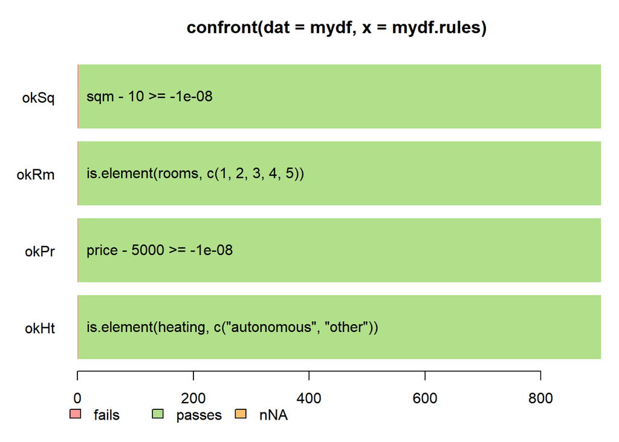

```r
barplot(qual.check, xlab = "")
```

These results confirm our previous observations. Moreover, there are 2 mistakes found in “sqm”, not just 1. We can also explore the row for which “rooms” is -1:

```r
head(mydf[which(mydf$sqm<10), 1:12])
```

|  | id | price | sqm | floor | rooms | bathrooms | terrace | alarm | heating | ac | parking | furnished |
| --- | --- | --- | --- | --- | --- | --- | --- | --- | --- | --- | --- | --- |
| 399 | 99361 | 80000 | 1 | 1 | 2 | 1 | 0 | 0 | autonomous | 1 | 0 | 0 |
| 801 | 197230 | 125000 | 0 | 3 | 4 | 1 | 0 | 0 | autonomous | 0 | 0 | 0 |

```r
head(mydf[which(mydf$rooms==-1), 1:12])
```

|  | id | price | sqm | floor | rooms | bathrooms | terrace | alarm | heating | ac | parking | furnished |
| --- | --- | --- | --- | --- | --- | --- | --- | --- | --- | --- | --- | --- |
| 601 | 147290 | 12000 | 120 | 1 | -1 | 1 | 0 | 0 | autonomous | 0 | 0 | 0 |

As seen, there are two properties with erratic values for “sqm”, and the real value can not be deducted just by looking at the rest of the variables. It will be specified in the next section how these mistakes will be handled. Moreover, the property with -1 rooms points to an imputation error, as the value for “sqm” and “bathrooms” make sense.

We can now start applying the different corrections to the data:

```r
#NB as I will start making modifications, a new df will be created (df) with the same content of the existing one, changing, replacing or deleting the content of the original df is a bad practice of data cleaning!

#dropping the id column
df <- subset(mydf, select = -c(id) )

#price=1000 to NA
df$price<-ifelse(df$price==1000,NA ,df$price)
#then convert to numerical
df$price<-as.numeric(df$price)

#sqm=0 and sqm=1 to NA
df$sqm<-ifelse(df$sqm==0,NA ,df$sqm)
df$sqm<-ifelse(df$sqm==1,NA ,df$sqm)
#then convert to numerical
df$sqm<-as.numeric(df$sqm)

#-1 in rooms to 1
levels(df$rooms) <- c(1,2,3,4,5)

#heating 3 levels to 2
df[which(df$heating=="autonamous"), "heating"] <- "autonomous"
df <- droplevels(df)
```

Now, we can check for NA’s:

```r
summary(df)
```

```
##      price             sqm        floor   rooms   bathrooms terrace alarm
##  Min.   :  7900   Min.   : 29.0   1:443   1:  1   1:548     0:783   0:898
##  1st Qu.: 75000   1st Qu.: 75.0   2:284   2:162   2:319     1:121   1:  6
##  Median :120000   Median :100.0   3:119   3:355   3: 37
##  Mean   :141926   Mean   :115.4   4: 35   4:233
##  3rd Qu.:185000   3rd Qu.:130.0   5: 16   5:153
##  Max.   :495000   Max.   :934.0   6:  5
##  NA's   :1        NA's   :2       7:  2
##        heating    ac      parking furnished
##  autonomous:807   0:598   0:893   0:841
##  other     : 97   1:306   1: 11   1: 63
##
##
##
##
##
```

As seen, there are 3 NA’s (imputed in the previous steps). We know that there are no empty cells (““) or other values representing NA’s (”?“), since we can check the variables types above, being all numeric (would not allow for character imputation) or categorical (would show the incorrect imputation as a new level).

We can deal with NA’s in different ways, like deleting those rows, however, I am going to impute different values with the hopes of obtaining a more robust model. Therefore, both for “price” and “sqm”, the median value for that variable (meeting the requisites of same room and bathroom numbers) will be imputed. The median is chosen over the mean, as it is not as sensible to extreme values.

```r
head(df[which(is.na(df$price)), 1:11])
```

|  | price | sqm | floor | rooms | bathrooms | terrace | alarm | heating | ac | parking | furnished |
| --- | --- | --- | --- | --- | --- | --- | --- | --- | --- | --- | --- |
| 834 | NA | 100 | 1 | 4 | 2 | 0 | 0 | autonomous | 0 | 0 | 0 |

```r
head(df[which(is.na(df$sqm)), 1:11])
```

|  | price | sqm | floor | rooms | bathrooms | terrace | alarm | heating | ac | parking | furnished |
| --- | --- | --- | --- | --- | --- | --- | --- | --- | --- | --- | --- |
| 399 | 80000 | NA | 1 | 2 | 1 | 0 | 0 | autonomous | 1 | 0 | 0 |
| 801 | 125000 | NA | 3 | 4 | 1 | 0 | 0 | autonomous | 0 | 0 | 0 |

```r
dummy_df <- df[-c(834), ] #Creating a dummy df just to calculate the median values dropping the rows containing NA
dummy_df2 <- df[-c(399, 801),]

#Imputing the median price
df[834, "price"] <- median(dummy_df$price[dummy_df$rooms == 4 & dummy_df$bathrooms == 2 & dummy_df$sqm == 100])

#Imputing the median sqm
df[399, "sqm"] <- median(dummy_df2$sqm[dummy_df2$rooms == 2 & dummy_df2$bathrooms == 1])
df[801, "sqm"] <- median(dummy_df2$sqm[dummy_df2$rooms == 4 & dummy_df2$bathrooms == 1])
```

Now we have a clean dataframe free of errors and missing values.

## 1.3 Data cleaning

To sum up:

- The variables’ names were simplified, the row enumeration was corrected, and the “id” column was dropped as it does not provide valuable information. These changes help for easier manipulation of the data.
- The categorical variables’ types were incorrect: some were defined as numerical variables, some others as integers, and one of them as character, so the correct way to proceed was to define them as factors.
- Specific mistakes were spotted: A minimum value for the variable “price” of 1000, two implausible values for “sqm” (0 and 1), an imputation error for “rooms” (-1), and lastly, a spelling mistake for one of the levels in “heating”. Firstly, the values aforementioned of “price” and “sqm” were replaced by NA’s temporarily. As these are the only NA’s in the whole dataframe, the method chosen to deal with them was median imputation. Secondly, the value -1 for “rooms” is assumed to be an imputation error, and is corrected to 1, and lastly, the erratic level “autonamous” for “heating” has been turned into “autonomous”.

# 2. Exploratory Data Analysis (EDA)

## 2.1 EDA plan

For a complete EDA, the following steps will be followed:

- What type of data do we have? Seen in the summary statistics portrayed previously.
- How is each variable distributed? We need graphical visualization. For this, the distribution of the continuous numerical variables (“price” and “sqm”) will be represented as histograms, while the categorical variables will be portrayed as frequency count barplots.
- Is there correlation among variables? To address this, firstly, the dependent variable “price” will be studied against the other continuous numerical variable “sqm”. Posteriorly, the relation of “price” with the categorical variables will be portrayed with boxplots, as they are an easy way to visually compare the differences between levels regarding means and IQRs.

## 2.2 EDA and summary of results

We have 2 numerical variables (“price”, “sqm”), and the rest of variables are considered categorical, as seen in the summary statistics before.

Secondly, to visualize the distribution of the continuous variables:

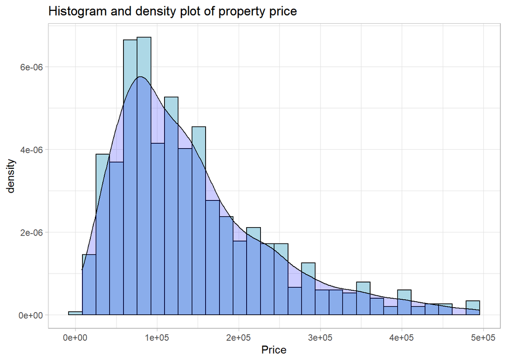

```r
#price
ggplot(df, aes(x=price)) +
  geom_histogram(aes(y=..density..),
                 #binwidth=1,
                 colour="black", fill="light blue") +
  geom_density(alpha=.2, fill="blue") +
  xlab("Price") +
  ggtitle("Histogram and density plot of property price") +
  theme_light()
```

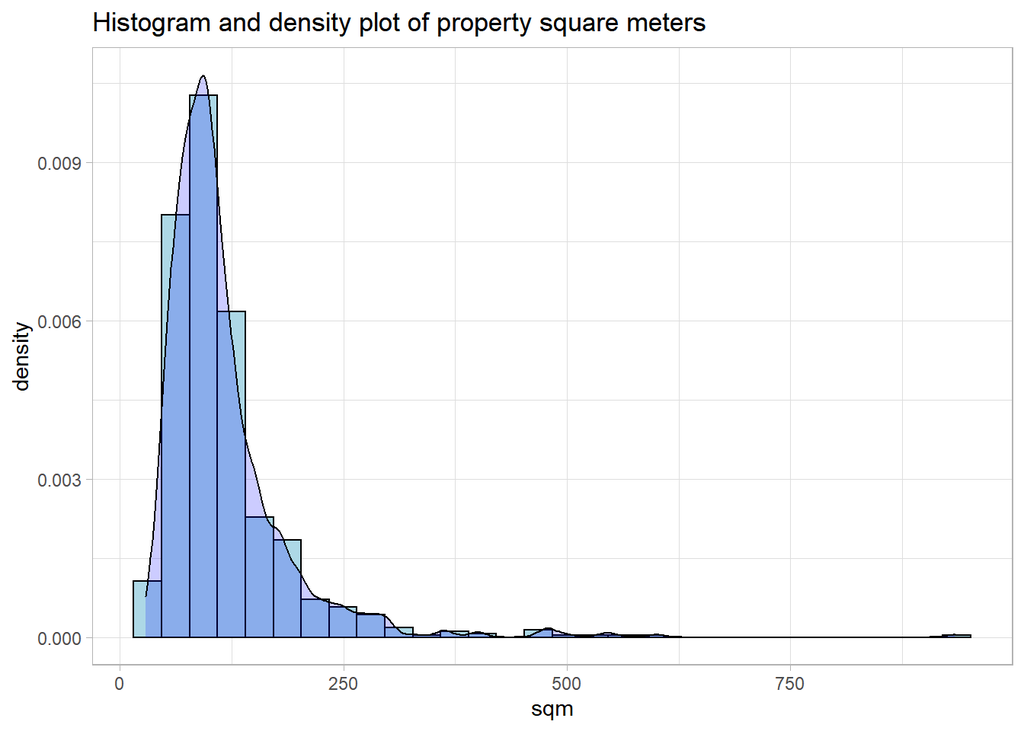

```r
#sqm
ggplot(df, aes(x=sqm)) +
  geom_histogram(aes(y=..density..),
                 #binwidth=1,
                 colour="black", fill="light blue") +
  geom_density(alpha=.2, fill="blue") +
  xlab("sqm") +
  ggtitle("Histogram and density plot of property square meters") +
  theme_light()
```

Neither looks normally distributed, and they both are positively skewed.

For the categorical variables:

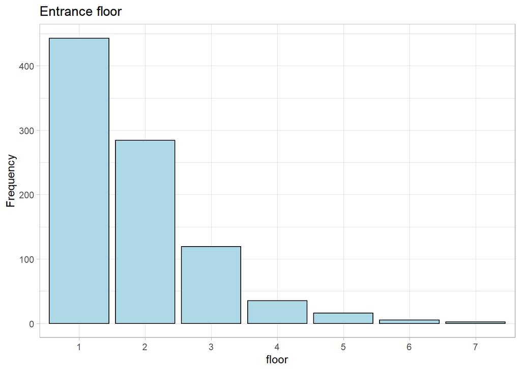

```r
#floor
ggplot(df)+ geom_bar(aes(x=floor), colour="black", fill="light blue") +
  labs(title = "Entrance floor") +
  scale_y_continuous(name="Frequency") +
  theme_light()
```

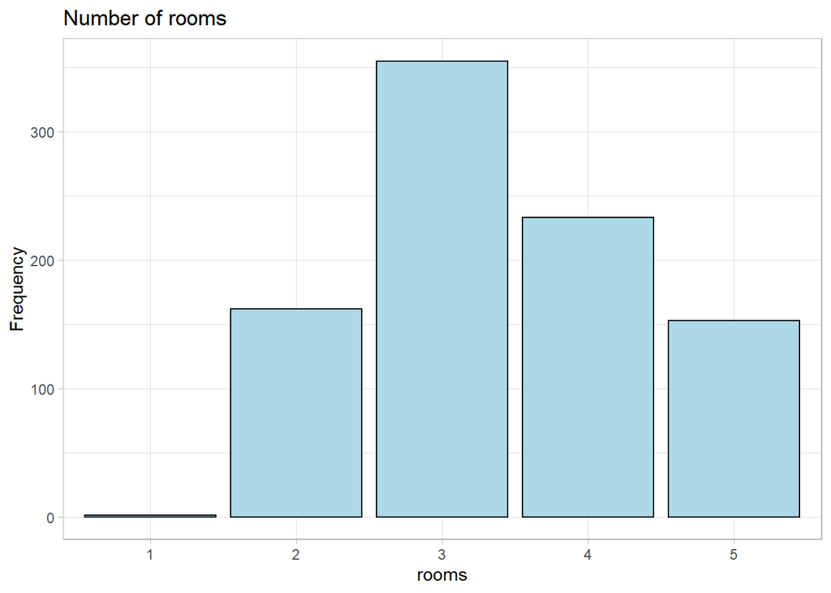

```r
#rooms
ggplot(df)+ geom_bar(aes(x=rooms), colour="black", fill="light blue") +
  labs(title = "Number of rooms") +
  scale_y_continuous(name="Frequency") +
  theme_light()
```

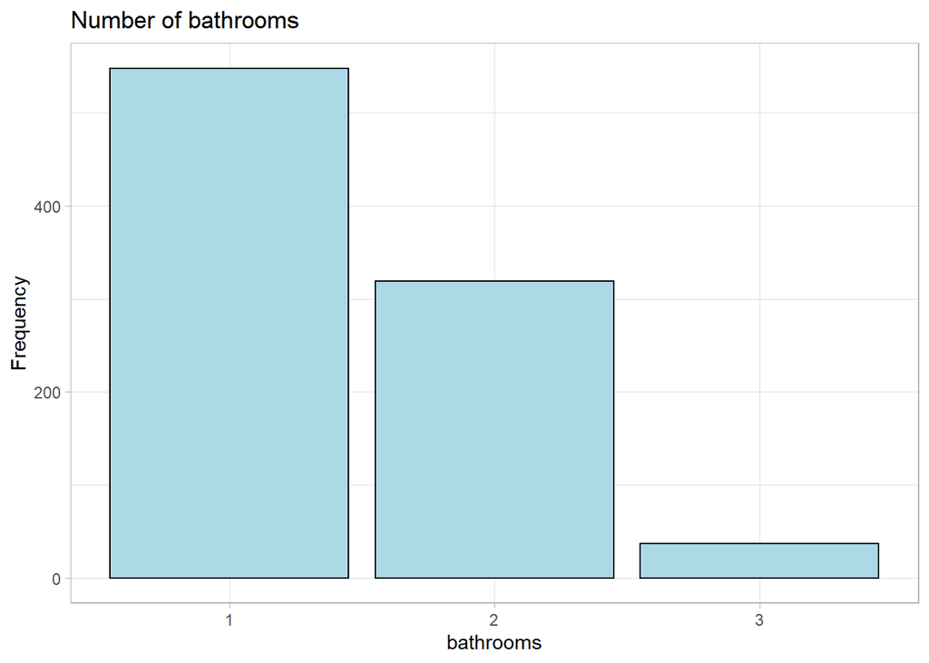

```r
#bathrooms
ggplot(df)+ geom_bar(aes(x=bathrooms), colour="black", fill="light blue") +
  labs(title = "Number of bathrooms") +
  scale_y_continuous(name="Frequency") +
  theme_light()
```

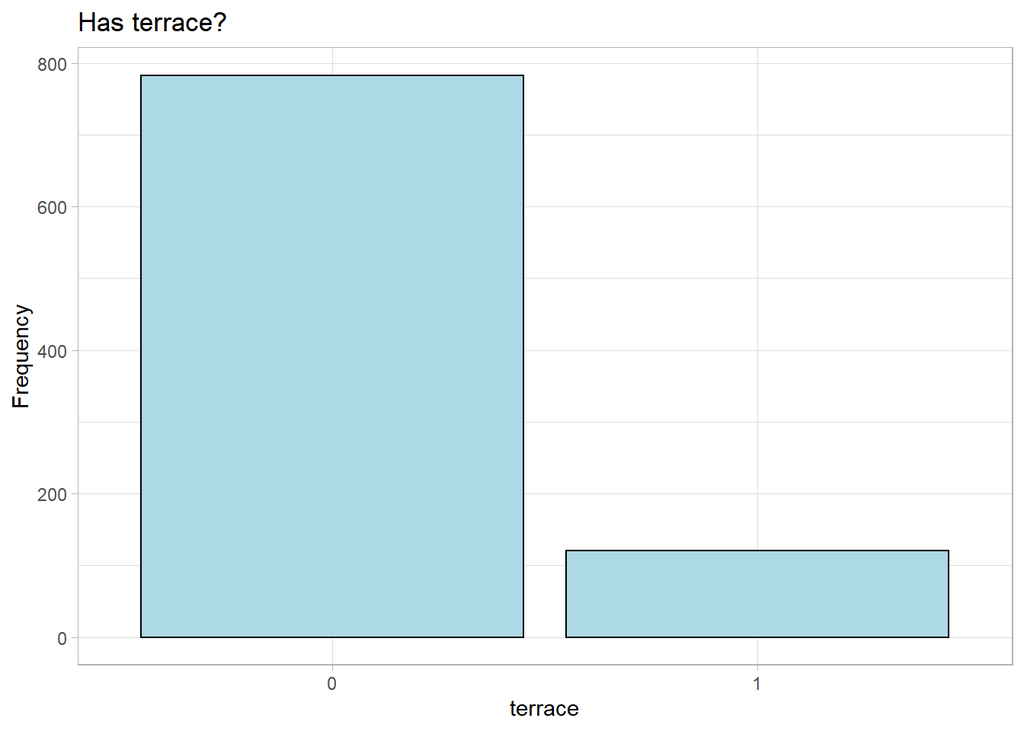

```r
#terrace
ggplot(df)+ geom_bar(aes(x=terrace), colour="black", fill="light blue") +
  labs(title = "Has terrace?") +
  scale_y_continuous(name="Frequency") +
  theme_light()
```

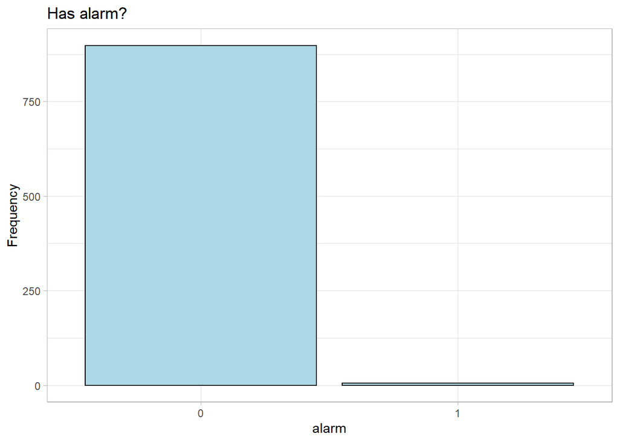

```r
#alarm
ggplot(df)+ geom_bar(aes(x=alarm), colour="black", fill="light blue") +
  labs(title = "Has alarm?") +
  scale_y_continuous(name="Frequency") +
  theme_light()
```

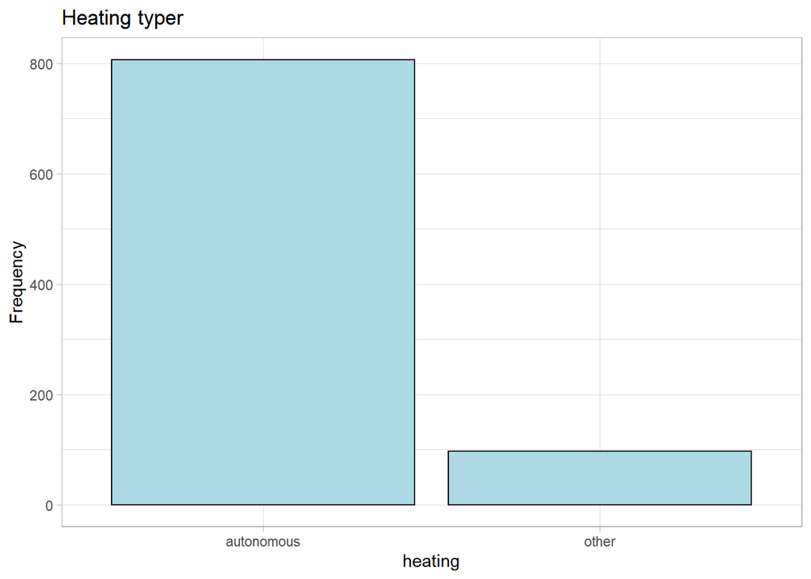

```r
#heating
ggplot(df)+ geom_bar(aes(x=heating), colour="black", fill="light blue") +
  labs(title = "Heating typer") +
  scale_y_continuous(name="Frequency") +
  theme_light()
```

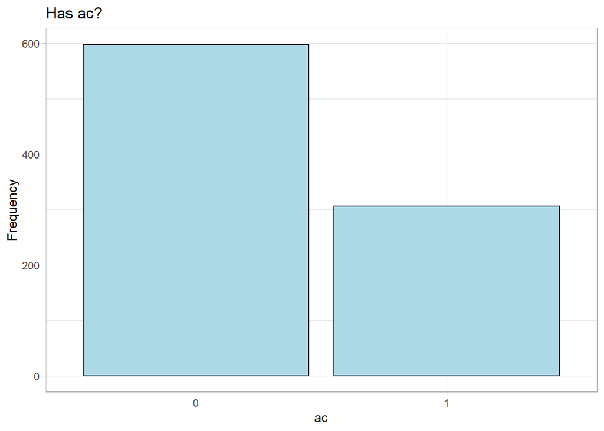

```r
#ac
ggplot(df)+ geom_bar(aes(x=ac), colour="black", fill="light blue") +
  labs(title = "Has ac?") +
  scale_y_continuous(name="Frequency") +
  theme_light()
```

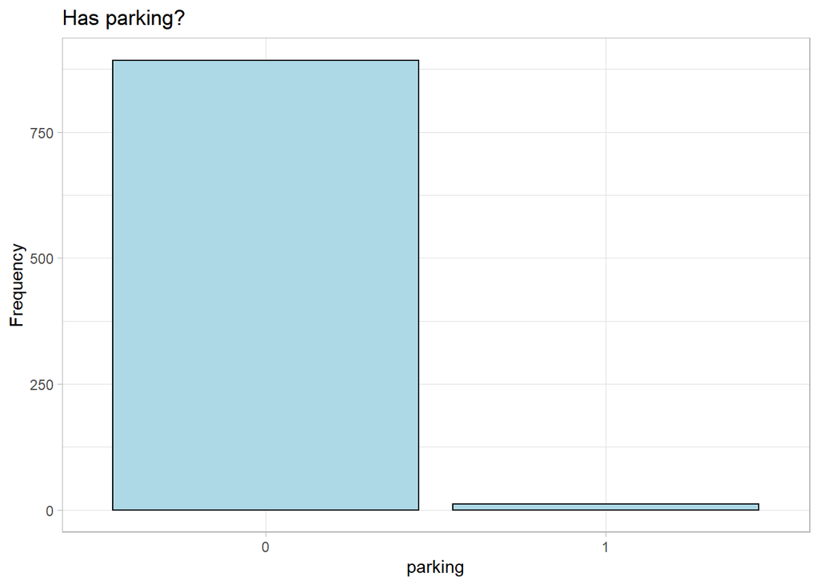

```r
#parking
ggplot(df)+ geom_bar(aes(x=parking), colour="black", fill="light blue") +
  labs(title = "Has parking?") +
  scale_y_continuous(name="Frequency") +
  theme_light()
```

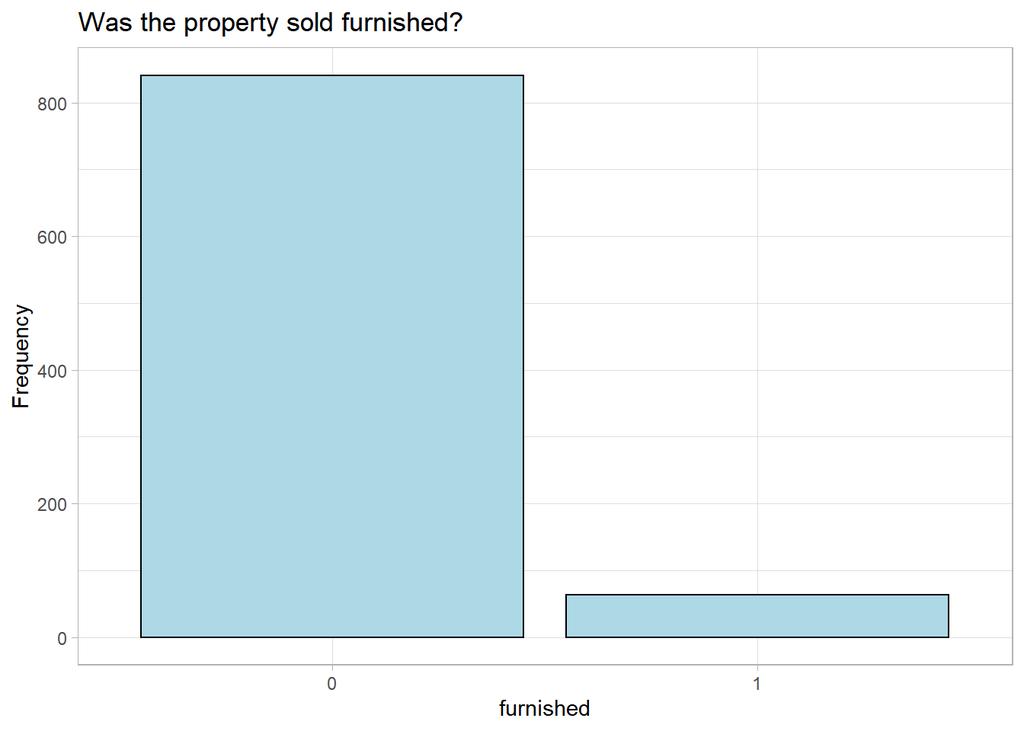

```r
#furnished
ggplot(df)+ geom_bar(aes(x=furnished), colour="black", fill="light blue") +
  labs(title = "Was the property sold furnished?") +
  scale_y_continuous(name="Frequency") +
  theme_light()
```

It can be seen how the categorical variables are, generally, unevenly distributed. The trend in “floor” shows that higher floors are less frequent. Also, the mode for the number of rooms is 3, and 1 for bathrooms. The rest of the distributions look very uneven.

To test the correlation between numerical variables, “price” and “sqm”, we should first test for normality. Visually, it did not seem they were normally distributed, but we can double-check with Shapiro’s test for normality, being our hypothesis H0 the variable being normally distributed:

```r
shapiro.test(df$price)
```

```
##
##  Shapiro-Wilk normality test
##
## data:  df$price
## W = 0.89856, p-value < 2.2e-16
```

```r
shapiro.test(df$sqm)
```

```
##
##  Shapiro-Wilk normality test
##
## data:  df$sqm
## W = 0.7034, p-value < 2.2e-16
```

Both p-values are very small (<0.05) so we can reject the null hypothesis H0 and state that these variables are not normally distributed. Therefore, and to assess the correlation numerically, we will have to run a correlation test using Spearman’s method:

```r
cor.test(df$price, df$sqm, method = "spearman")
```

```
##
##  Spearman's rank correlation rho
##
## data:  df$price and df$sqm
## S = 76991002, p-value < 2.2e-16
## alternative hypothesis: true rho is not equal to 0
## sample estimates:
##       rho
## 0.3747028
```

There is a slight positive correlation (0.37) between both continuous variables. We can visually confirm this:

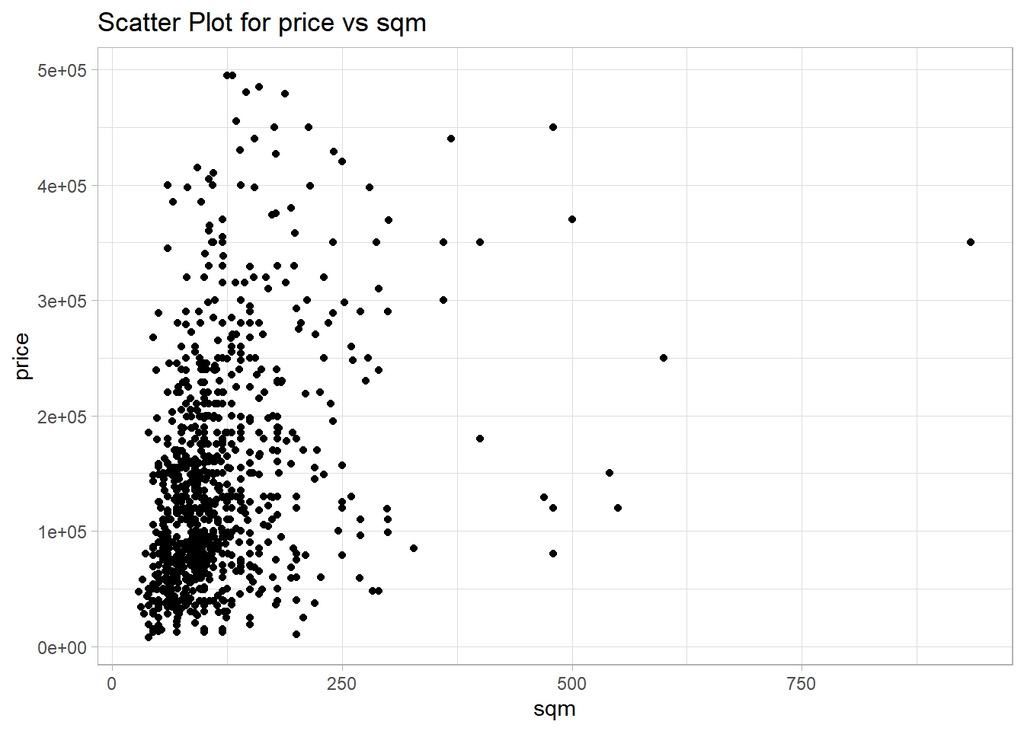

```r
ggplot(data=df, aes(x=sqm, y=price)) + geom_point() + theme_light() +
  ggtitle("Scatter Plot for price vs sqm")
```

As seen, higher values of “sqm” correspond to higher values of “price”, although this relationship is not very strong. From the graph above, it can be seen how for higher values, the variance increases drastically.

Now we can study how the categorical variables covary with respect to the dependent variable “price”:

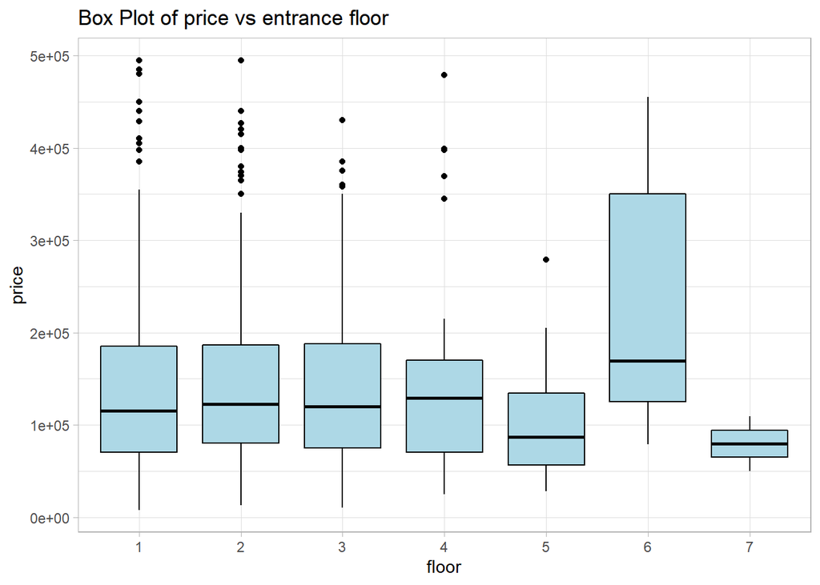

```r
#floor vs price
ggplot(df, aes(x=price, y=floor)) +
  geom_boxplot(colour = "black", fill="lightblue") +
  theme_light() +
  labs(title="Box Plot of price vs entrance floor") +
  coord_flip()
```

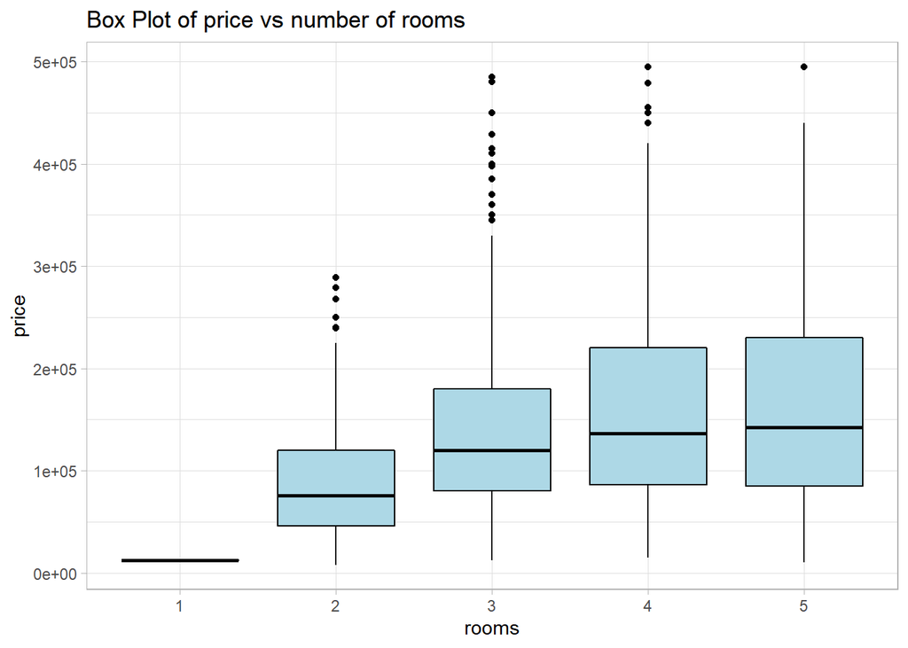

```r
#rooms vs price
ggplot(df, aes(x=price, y=rooms)) +
  geom_boxplot(colour = "black", fill="lightblue") +
  theme_light() +
  labs(title="Box Plot of price vs number of rooms") +
  coord_flip()
```

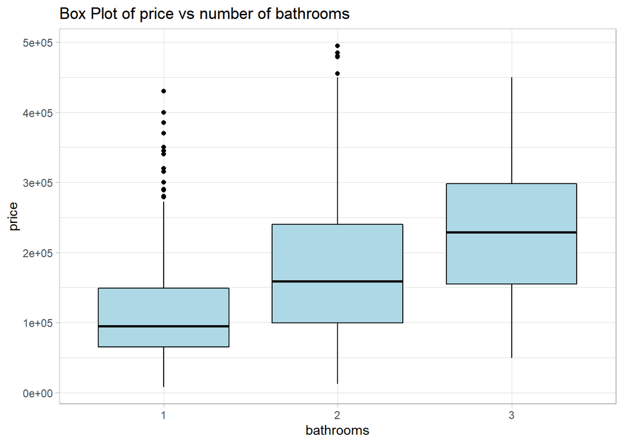

```r
#bathrooms vs price
ggplot(df, aes(x=price, y=bathrooms)) +
  geom_boxplot(colour = "black", fill="lightblue") +
  theme_light() +
  labs(title="Box Plot of price vs number of bathrooms") +
  coord_flip()
```

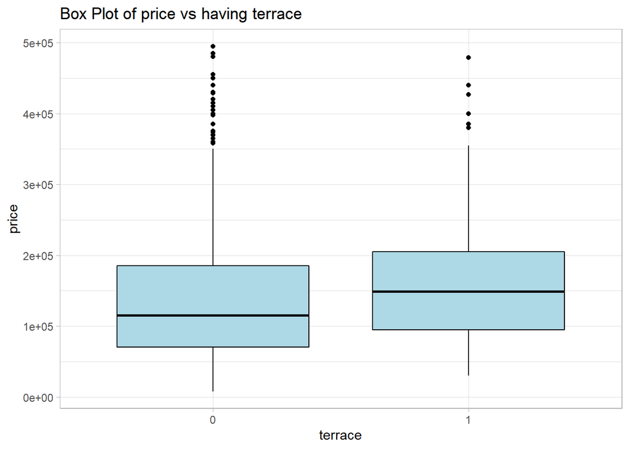

```r
#terrace vs price
ggplot(df, aes(x=price, y=terrace)) +
  geom_boxplot(colour = "black", fill="lightblue") +
  theme_light() +
  labs(title="Box Plot of price vs having terrace") +
  coord_flip()
```

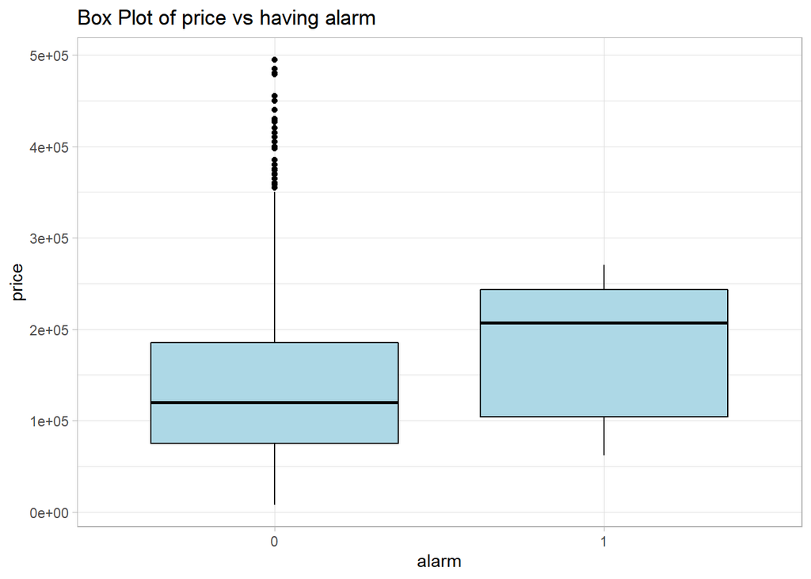

```r
#alarm vs price
ggplot(df, aes(x=price, y=alarm)) +
  geom_boxplot(colour = "black", fill="lightblue") +
  theme_light() +
  labs(title="Box Plot of price vs having alarm") +
  coord_flip()
```

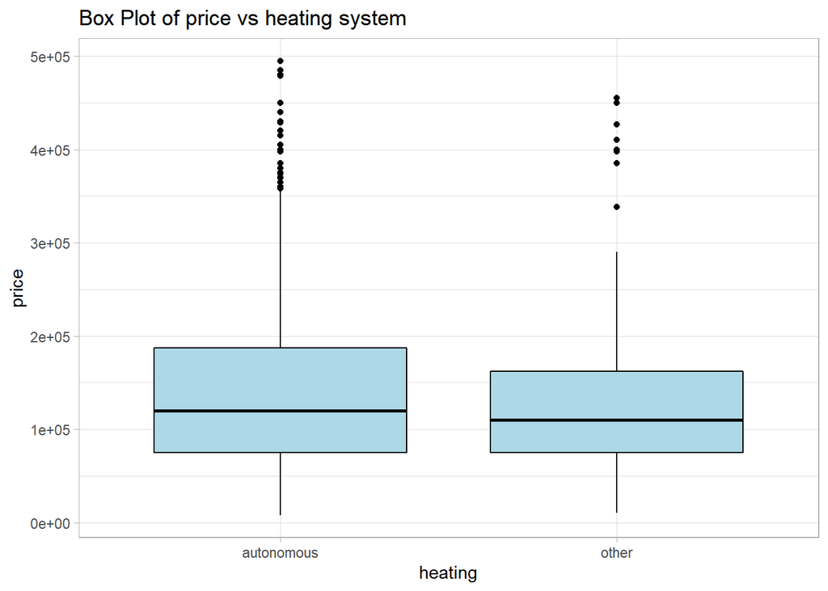

```r
#heating vs price
ggplot(df, aes(x=price, y=heating)) +
  geom_boxplot(colour = "black", fill="lightblue") +
  theme_light() +
  labs(title="Box Plot of price vs heating system") +
  coord_flip()
```